# Breast Cancer Fine-Gray Model Setup

## Load Data

```r
breast_raw <- read_csv(
  "data/Breast Cancer METABRIC.csv",  # read the METABRIC dataset
  show_col_types = FALSE
)

breast <- breast_raw %>%
  mutate(
    os_months = as.numeric(`Overall Survival (Months)`),  # overall survival time in months
    vital_status = na_if(`Patient's Vital Status`, ""),  # disease death / other death / living
    age_dx = as.numeric(`Age at Diagnosis`),  # age at diagnosis
    tumor_size = as.numeric(`Tumor Size`),  # tumor size
    tumor_stage = factor(na_if(as.character(`Tumor Stage`), "NA")),  # tumor stage
    hist_grade = factor(na_if(as.character(`Neoplasm Histologic Grade`), "NA")),  # histologic grade
    er_status = factor(na_if(`ER Status`, "")),  # ER status
    pr_status = factor(na_if(`PR Status`, "")),  # PR status
    her2_status = factor(na_if(`HER2 Status`, ""))  # HER2 status
  )
```

## EDA

Taking a look at some of the rows of the data.

```r
breast_preview <- breast %>%
  select(`Patient ID`, os_months, vital_status, age_dx, tumor_size, tumor_stage, hist_grade) %>%
  slice_head(n = 6)
```

```
# # A tibble: 6 × 7
#   `Patient ID` os_months vital_status   age_dx tumor_size tumor_stage hist_grade
#   <chr>            <dbl> <chr>           <dbl>      <dbl> <fct>       <fct>
# 1 MB-0000          140.  Living           75.6         22 2           3
# 2 MB-0002           84.6 Living           43.2         10 1           3
# 3 MB-0005          164.  Died of Disea…   48.9         15 2           2
# 4 MB-0006          165.  Living           47.7         25 2           2
# 5 MB-0008           41.4 Died of Disea…   77.0         40 2           3
# 6 MB-0010            7.8 Died of Disea…   78.8         31 4           3
```

Plotting the distributions of age at diagnosis and vital status.

```
# Warning: Removed 11 rows containing non-finite outside the scale range
# (`stat_bin()`).
```

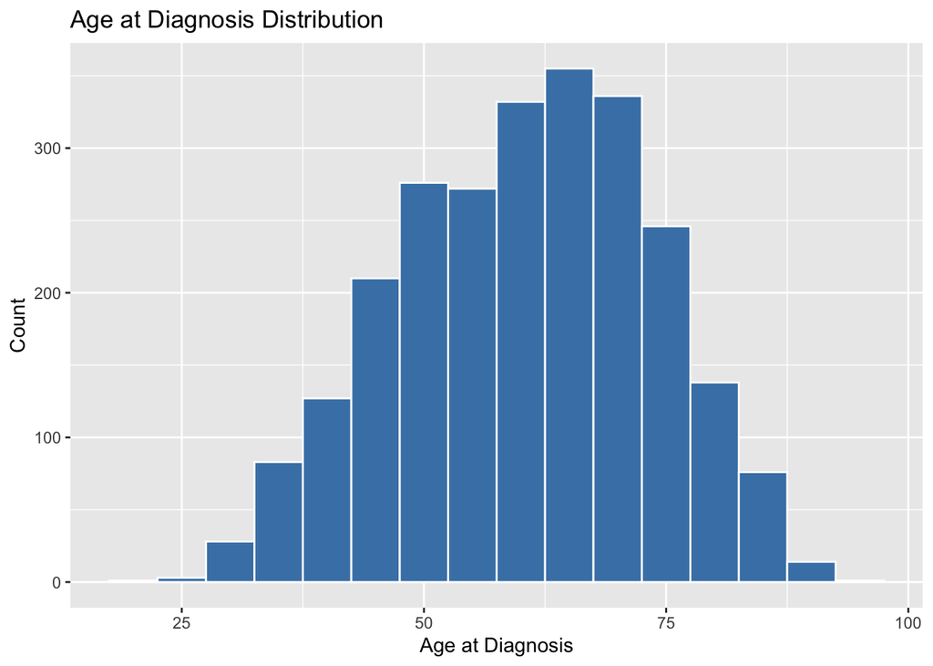

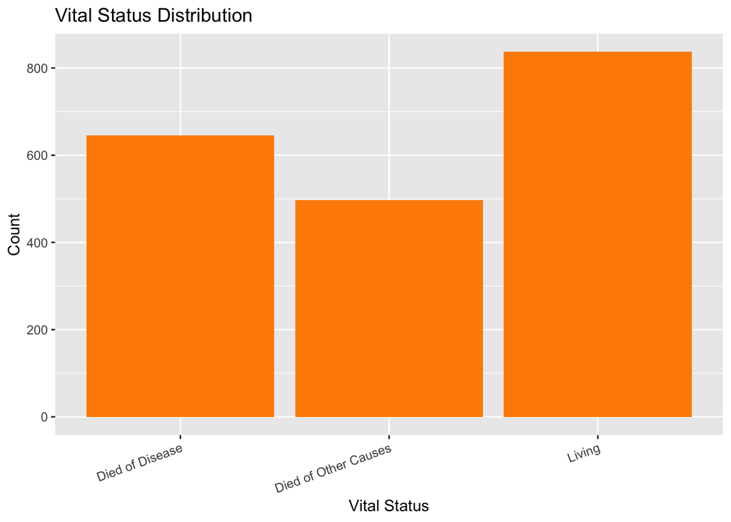

```r
age_plot <- breast %>%
  ggplot(aes(x = age_dx)) +
  geom_histogram(binwidth = 5, fill = "steelblue", color = "white") +
  labs(title = "Age at Diagnosis Distribution", x = "Age at Diagnosis", y = "Count")

status_plot <- breast %>%
  filter(!is.na(vital_status)) %>%
  ggplot(aes(x = vital_status)) +
  geom_bar(fill = "darkorange") +
  labs(title = "Vital Status Distribution", x = "Vital Status", y = "Count") +
  theme(axis.text.x = element_text(angle = 20, hjust = 1))
```

```r
breast_summary <- breast %>%
  summarise(
    patients = n(),  # total number of patients
    os_time_missing = sum(is.na(os_months)),  # missing overall survival times
    vital_status_missing = sum(is.na(vital_status)),  # missing vital status labels
    median_age_dx = median(age_dx, na.rm = TRUE),  # median age at diagnosis
    median_os_months = median(os_months, na.rm = TRUE)  # median observed OS time
  )
```

```
# # A tibble: 1 × 5
#   patients os_time_missing vital_status_missing median_age_dx median_os_months
#      <int>           <int>                <int>         <dbl>            <dbl>
# 1     2509             528                  529          61.1             116.
```

The dataset `Breast Cancer METABRIC.csv` contains 2,509 observations and includes overall survival time, relapse information, and clinical tumor characteristics. **For the Fine-Gray model, I will focus on disease-specific death as the event of interest and other-cause death as the competing event.**

## Building the Fine-Gray model

For this notebook, I am using a competing-risks analysis. That means I will use overall survival time together with a three-level event code: `0` for censored/living, `1` for died of disease, and `2` for died of other causes.

### Step 1: Build the competing-risk modeling dataset

Keep only the variables needed for the Fine-Gray model and create the competing-risk event code.

```r
breast_fg_data <- breast %>%
  transmute(
    patient_id = `Patient ID`,
    os_months,
    fg_status = case_when(
      vital_status == "Living" ~ 0L,
      vital_status == "Died of Disease" ~ 1L,
      vital_status == "Died of Other Causes" ~ 2L,
      TRUE ~ NA_integer_
    ),
    age_dx,
    tumor_size,
    tumor_stage,
    hist_grade,
    er_status,
    pr_status,
    her2_status
  ) %>%
  drop_na()
```

Peep the new dataset

```
# Rows: 1,405
# Columns: 10
# $ patient_id  <chr> "MB-0000", "MB-0002", "MB-0005", "MB-0006", "MB-0008", "MB…
# $ os_months   <dbl> 140.50000, 84.63333, 163.70000, 164.93333, 41.36667, 7.800…
# $ fg_status   <int> 0, 0, 1, 0, 1, 1, 0, 1, 2, 2, 1, 1, 0, 0, 2, 0, 0, 0, 0, 0…
# $ age_dx      <dbl> 75.65, 43.19, 48.87, 47.68, 76.97, 78.77, 56.45, 70.00, 89…
# $ tumor_size  <dbl> 22, 10, 15, 25, 40, 31, 10, 65, 29, 16, 28, 22, 21, 19, 36…
# $ tumor_stage <fct> 2, 1, 2, 2, 2, 4, 2, 3, 2, 2, 2, 4, 1, 2, 2, 2, 2, 2, 2, 1…
# $ hist_grade  <fct> 3, 3, 2, 2, 3, 3, 2, 3, 2, 3, 2, 2, 1, 3, 3, 2, 2, 2, 3, 2…
# $ er_status   <fct> Positive, Positive, Positive, Positive, Positive, Positive…
# $ pr_status   <fct> Negative, Positive, Positive, Positive, Positive, Positive…
# $ her2_status <fct> Negative, Negative, Negative, Negative, Negative, Negative…
```

### Step 2: Create the Fine-Gray inputs

This is using the `cmprsk` package. Instead of a `Surv()` object, the Fine-Gray model takes three main pieces: a follow-up time, a competing-risk status variable, and a numeric matrix of predictor variables. Here, `breast_fg_time` stores the overall survival time in months, and `breast_fg_status` stores whether each patient was censored (`0`), died of disease (`1`), or died of other causes (`2`).

The last piece is `breast_fg_covariates`. The `crr()` function wants the predictors in numeric matrix form, so I use `model.matrix()` to convert the variables into the format the model needs. Continuous variables stay numeric, while factor variables like tumor stage or receptor status get expanded into indicator columns. I remove the first column afterward because that is just the intercept, and I do not need to pass that separately into `crr()`(NOTE I had a lot of help from ChatGPT here).

```r
breast_fg_time <- breast_fg_data$os_months
breast_fg_status <- breast_fg_data$fg_status

breast_fg_covariates <- model.matrix(
  ~ age_dx + tumor_size + tumor_stage + hist_grade + er_status + pr_status + her2_status,
  data = breast_fg_data
)[, -1, drop = FALSE]
```

```
# # A tibble: 6 × 2
#   os_months fg_status
#       <dbl>     <int>
# 1     140.          0
# 2      84.6         0
# 3     164.          1
# 4     165.          0
# 5      41.4         1
# 6       7.8         1
```

### Step 3: Fit the Fine-Gray model

Using the `cmprsk` package again, I fit a Fine-Gray competing-risks model following the documentation.

```r
breast_fg_model <- crr(
  ftime = breast_fg_time,
  fstatus = breast_fg_status,
  cov1 = breast_fg_covariates,
  failcode = 1,
  cencode = 0
)
```

```
# convergence:  TRUE
# coefficients:
#              age_dx          tumor_size        tumor_stage1        tumor_stage2
#           -0.006486            0.010980            9.297000            9.722000
#        tumor_stage3        tumor_stage4         hist_grade2         hist_grade3
#           10.150000           11.440000            0.396000            0.707700
#   er_statusPositive   pr_statusPositive her2_statusPositive
#           -0.091920           -0.101300            0.478300
# standard errors:
#  [1] 0.003978 0.003067 1.021000 1.014000 1.014000 1.081000 0.232500 0.230200
#  [9] 0.139100 0.114200 0.135900
# two-sided p-values:
#              age_dx          tumor_size        tumor_stage1        tumor_stage2
#             0.10000             0.00034             0.00000             0.00000
#        tumor_stage3        tumor_stage4         hist_grade2         hist_grade3
#             0.00000             0.00000             0.08900             0.00210
#   er_statusPositive   pr_statusPositive her2_statusPositive
#             0.51000             0.38000             0.00043
```

### Step 4: Analysis and Visualization

This Fine-Gray model mostly confirms what we would expect clinically. The strongest signal comes from tumor stage, where the coefficients are extremely large and positive, ranging from about 9.30 to 11.44, which indicates a much higher risk of disease-specific death as stage increases. Grade 3 tumors also point in the same direction, with a positive coefficient of about 0.71, suggesting higher-risk disease than the reference grade.

The model also shows a positive effect for tumor size (0.011) and HER2-positive status (0.48), which both support the same general story of more aggressive disease being linked to worse outcomes. So overall, the Fine-Gray model is not giving a surprising result here. Instead, it is largely confirming, with data and coefficients, what we would already expect: more advanced and more aggressive tumor features are associated with a greater risk of death from disease.

The cumulative incidence plot below shows disease-specific death over time by tumor stage. This is a good fit for a Fine-Gray workflow because it respects the competing-risk setup instead of treating other-cause death like ordinary censoring.

```r
breast_stage_cuminc_data <- breast_fg_data %>%
  filter(tumor_stage %in% c("1", "2", "3", "4"))

breast_stage_cuminc <- cuminc(
  ftime = breast_stage_cuminc_data$os_months,
  fstatus = breast_stage_cuminc_data$fg_status,
  group = breast_stage_cuminc_data$tumor_stage
)

stage_colors <- c(
  "1" = "#1b9e77",
  "2" = "#377eb8",
  "3" = "#e67e22",
  "4" = "#d62728"
)
```

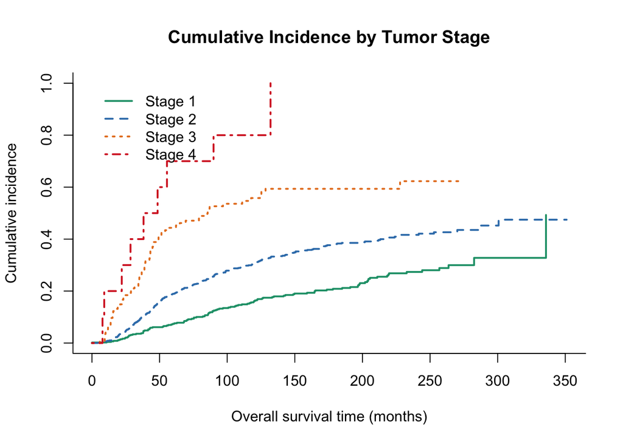

The forest plot below turns the Fine-Gray coefficients into subdistribution hazard ratios with confidence intervals. Points to the right of `1` suggest higher disease-specific risk, while points to the left of `1` suggest lower risk.

```
# `height` was translated to `width`.
```

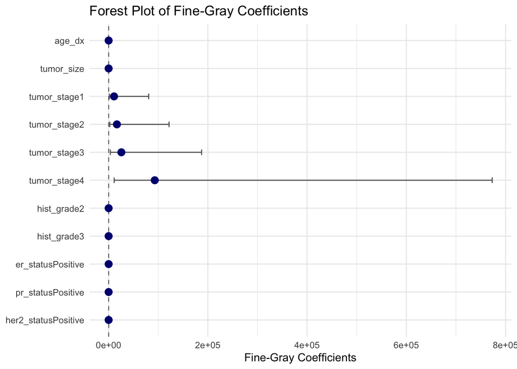

```r
fg_coef <- breast_fg_model$coef
fg_se <- sqrt(diag(breast_fg_model$var))

fg_forest_data <- tibble(
  term = names(fg_coef),
  coefficient = unname(fg_coef),
  subdistribution_hr = exp(unname(fg_coef)),
  conf_low = exp(fg_coef - qnorm(0.975) * fg_se),
  conf_high = exp(fg_coef + qnorm(0.975) * fg_se)
) %>%
  mutate(term = factor(term, levels = rev(term)))

fg_forest_plot <- ggplot(fg_forest_data, aes(x = subdistribution_hr, y = term)) +
  geom_vline(xintercept = 1, linetype = "dashed", color = "gray50") +
  geom_errorbarh(aes(xmin = conf_low, xmax = conf_high), height = 0.2, color = "gray40") +
  geom_point(size = 3, color = "navy") +
  labs(
    title = "Forest Plot of Fine-Gray Coefficients",
    x = "Fine-Gray Coefficients",
    y = NULL
  ) +
  theme_minimal()
# Warning: `geom_errorbarh()` was deprecated in ggplot2 4.0.0.
# ℹ Please use the `orientation` argument of `geom_errorbar()` instead.
# This warning is displayed once per session.
# Call `lifecycle::last_lifecycle_warnings()` to see where this warning was generated.
```